# R Notebook Analysing Stroke Data

# PHS Scottish Stroke Statistics

This notebook contains explorative analysis and visualisations of stroke incidence and mortality data across Scotland.

- Raw datasets are from PHS open data accessible via: https://www.opendata.nhs.scot/dataset/scottish-stroke-statistics
- The raw datasets have been cleaned and saved within the folder “../clean_data/” the cleaned datafiles will be used and analysed here.
- Data exploration, analysis and visualisations are covered in this notebook.

Note: this notebook and its visualisations are not exhaustive, not all types of visualisations/analysis are covered.

## Other analysis types covered in separate notebooks:

For the analysis and construction of the predictive model please check the notebook: **modelling_stroke_data.Rmd**

For the clustering analysis, please check the notebook: **clustering_stroke_data.Rmd**

For the spatial analysis, creating a map with leaflet, please check the notebook: **analysing_spatial_stroke_data.Rmd**

```r
# load in libraries
library(tidyverse)
library(skimr)
```

### Contents

For the analysis and visualisations I focus on (health board level):

1. Stroke activity - demographics (age, sex) - distribution across Scotland
2. Stroke mortality - demographics (age, sex) - distribution across Scotland

### 1. Load in cleaned datafiles

```r
#stroke activity per healthboard
activity_hb <- read_csv("../clean_data/stroke_activity_healthboard.csv")
#stroke activity per council area
activity_ca <- read_csv("../clean_data/stroke_activity_council.csv")
# stroke mortality per healthboard
mortality_hb <- read_csv("../clean_data/stroke_mortality_healthboard.csv")
# stroke mortality per council area
mortality_ca <- read_csv("../clean_data/stroke_mortality_council.csv")
# additional datafile 'table2_mortality_stroke_2023_01_24.csv' from
# https://publichealthscotland.scot/publications/scottish-stroke-statistics/scottish-stroke-statistics-year-ending-31-march-2022/
# showing mortality rates per SIMD quantile
mortality_simd <- read_csv("../clean_data/cd_mortality_by_deprivation.csv")
```

### 2. General exploration data contents

Initially we focus on Health boards as data contents are similar except for area (health board vs. council area).

```r
# general exploration activity

head(activity_hb)
```

| ...1 | id | financial_year | hbr | hbrqf | admission_type | admission_type_qf | age_group | age_group_qf | sex | sex_qf | diagnosis | number_of_discharges | number_of_discharges_qf | crude_rate | crude_rate_qf | easr |
| --- | --- | --- | --- | --- | --- | --- | --- | --- | --- | --- | --- | --- | --- | --- | --- | --- |
| 1 | 1 | 2012/13 | S08000015 | NA | All | d | 0-44 years | NA | Males | NA | Cerebrovascular Disease | 44 | NA | 46.79905 | NA | 52.26475 |
| 2 | 2 | 2012/13 | S08000015 | NA | All | d | 0-44 years | NA | Females | NA | Cerebrovascular Disease | 24 | NA | 24.85321 | NA | 23.08848 |
| 3 | 3 | 2012/13 | S08000015 | NA | All | d | 45-64 years | NA | Males | NA | Cerebrovascular Disease | 212 | NA | 408.40702 | NA | 406.31556 |
| 4 | 4 | 2012/13 | S08000015 | NA | All | d | 45-64 years | NA | Females | NA | Cerebrovascular Disease | 153 | NA | 272.52324 | NA | 274.07747 |
| 5 | 5 | 2012/13 | S08000015 | NA | All | d | 65-74 years | NA | Males | NA | Cerebrovascular Disease | 251 | NA | 1271.72316 | NA | 1309.38183 |
| 6 | 6 | 2012/13 | S08000015 | NA | All | d | 65-74 years | NA | Females | NA | Cerebrovascular Disease | 213 | NA | 967.87386 | NA | 977.96702 |

```r
view(activity_hb)

activity_hb %>%
  filter(age_group == "All") %>%
  filter(sex == "All")
```

| ...1 | id | financial_year | hbr | hbrqf | admission_type | admission_type_qf | age_group | age_group_qf | sex | sex_qf | diagnosis | number_of_discharges | number_of_discharges_qf | crude_rate | crude_rate_qf | easr |
| --- | --- | --- | --- | --- | --- | --- | --- | --- | --- | --- | --- | --- | --- | --- | --- | --- |
| 7206 | 7206 | 2012/13 | S08000015 | NA | All | d | All | d | All | d | Cerebrovascular Disease | 1739 | NA | 465.9450190 | NA | 468.9990481 |
| 7212 | 7212 | 2012/13 | S08000016 | NA | All | d | All | d | All | d | Cerebrovascular Disease | 610 | NA | 536.4052058 | NA | 494.3429608 |
| 7218 | 7218 | 2012/13 | S08000017 | NA | All | d | All | d | All | d | Cerebrovascular Disease | 914 | NA | 605.9400689 | NA | 543.9069945 |
| 7224 | 7224 | 2012/13 | S08000019 | NA | All | d | All | d | All | d | Cerebrovascular Disease | 1649 | NA | 551.3390618 | NA | 623.5552663 |
| 7230 | 7230 | 2012/13 | S08000020 | NA | All | d | All | d | All | d | Cerebrovascular Disease | 2482 | NA | 432.8566446 | NA | 508.6025448 |
| 7236 | 7236 | 2012/13 | S08000022 | NA | All | d | All | d | All | d | Cerebrovascular Disease | 1687 | NA | 527.5171982 | NA | 514.7649850 |
| 7242 | 7242 | 2012/13 | S08000024 | NA | All | d | All | d | All | d | Cerebrovascular Disease | 3948 | NA | 467.9166568 | NA | 573.2312346 |
| 7248 | 7248 | 2012/13 | S08000025 | NA | All | d | All | d | All | d | Cerebrovascular Disease | 123 | NA | 571.2958662 | NA | 533.3590985 |
| 7254 | 7254 | 2012/13 | S08000026 | NA | All | d | All | d | All | d | Cerebrovascular Disease | 63 | NA | 271.4347264 | NA | 294.0019666 |
| 7260 | 7260 | 2012/13 | S08000028 | NA | All | d | All | d | All | d | Cerebrovascular Disease | 141 | NA | 511.6110305 | NA | 460.6475078 |

[output cut: 990 more lines]

```r
activity_hb %>%
  distinct(financial_year)
```

| financial_year |
| --- |
| 2012/13 |
| 2013/14 |
| 2014/15 |
| 2015/16 |
| 2016/17 |
| 2017/18 |
| 2018/19 |
| 2019/20 |
| 2020/21 |
| 2021/22 |

```r
# data is spanning from 2012/2013 until 2021/22 = 10 years

activity_hb %>%
  distinct(admission_type)
```

| admission_type |
| --- |
| All |
| Elective |
| Emergency |
| Transfer |

```r
# 4 admission types: elective, emergency, transfer and all

activity_hb %>%
  distinct(age_group)
```

| age_group |
| --- |
| 0-44 years |
| 45-64 years |
| 65-74 years |
| 75plus years |
| All |
| under75 years |

```r
# 6 age groups: 0-44, 45-64, 65-74, 75+, all, under 75

activity_hb %>%
  distinct(diagnosis)
```

| diagnosis |
| --- |
| Cerebrovascular Disease |
| Stroke |
| Subarachnoid Haemorrhage |
| TIAs and related syndromes |

```r
# 4 diagnosis types: Cerebrovascular disease, stroke, Subarachnoid haemorrhage, TIAs and related symptoms

activity_hb %>%
  distinct(sex)
```

| sex |
| --- |
| Males |
| Females |
| All |

```r
# 3 sex types: Males, Females, All

activity_hb %>%
  distinct(hbr)
```

| hbr |
| --- |
| S08000015 |
| S08000016 |
| S08000017 |
| S08000019 |
| S08000020 |
| S08000022 |
| S08000024 |
| S08000025 |
| S08000026 |
| S08000028 |

[output cut: 5 more lines]

```r
# 14 healthboards and single code for whole of Scotland
```

[output not shown]

[output cut: 990 more lines]

**crude rate and easr** Two columns in all PHS open data files are of interest for data visualisation:

*crude rate:* The crude rate is the population-standardised rate of the ‘event’ (here: incidences or mortality rate) Crude rate is the number of events per 100.000 people

*EASR:* is the The European Age-Sex Standardised Rate per 100,000 population. The numbers of deaths per 100 000 population are influenced by the age distribution of the population. For standardisation the European Standard Population (ESP) is used to standardise on age and sex.

### Visualisations - are organised per data file / topic

- 3a = stroke activity per HB
- 3b = stroke mortality per HB
- 3c = mortality per simd (Scottish Index Multiple Deprivation)
- 4a = stroke activity per HB - demographics
- 4b = stroke mortality per HB - demographics
- 5 = Stroke mortality and incidences per health board
- 6 = Percentage change in incidence and mortality rates for period 2012-2021 for major demographics

#### 3A. General insights Stroke activity per HB

**What is the number of total stroke incidences in Scotland per year from 2012 to now?**

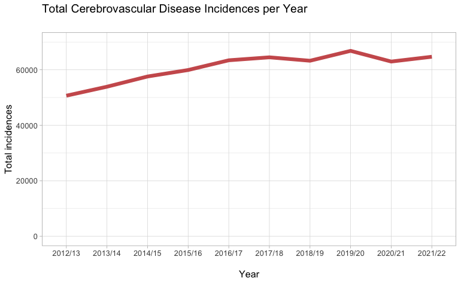

```r
activity_hb %>%
  select(financial_year, hbr, age_group, sex, admission_type, diagnosis, number_of_discharges, crude_rate, easr) %>%
  filter(age_group == "All",
         admission_type == "All",
         sex == "All",
         hbr == "S92000003") %>%
  group_by(financial_year) %>%
  summarise(total_stroke_incidences = sum(number_of_discharges)) %>%
  ggplot() +
  aes(x = financial_year, y = total_stroke_incidences) +
  geom_line(aes(group = 1), colour = "indianred", size = 2) +
  theme_light() +
  labs(
    x = "\nYear",
    y = "Total incidences",
    title = "Total Cerebrovascular Disease Incidences per Year\n"
  ) +
  scale_y_continuous(limits = c(0, 70000))
```

Data/graph shows the total number of stroke incidences in Scotland over the years 2012/13 - 2021/22. We see an initial increase until 2016 after incidence rates are more stable.

However this gives the absolute number of incidences, which are not standardised for age and sex composition differences in the population across years. Standardisation is important in order to enable comparison between different areas and demographics.

**age-sex standardised stroke incidences in Scotland per year**

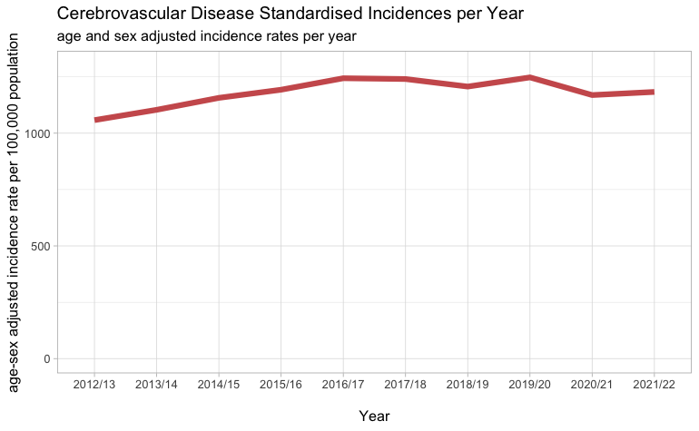

```r
activity_hb %>%
  select(financial_year, hbr, age_group, sex, admission_type, diagnosis, number_of_discharges, crude_rate, easr) %>%
  filter(age_group == "All",
         admission_type == "All",
         sex == "All",
         hbr == "S92000003") %>%
  group_by(financial_year) %>%
  summarise(total_incidences_easr = sum(easr)) %>%
  ggplot() +
  aes(x = financial_year, y = total_incidences_easr) +
  geom_line(aes(group = 1), colour = "indianred", size = 2) +
  theme_light() +
  labs(
    x = "\nYear",
    y = "age-sex adjusted incidence rate per 100,000 population",
    title = "Cerebrovascular Disease Standardised Incidences per Year",
    subtitle = "age and sex adjusted incidence rates per year"
  ) +
  scale_y_continuous(limits = c(0, 1300))
```

```r
NA
```

Data/graph shows the age-sex standardised incidence rate of stroke incidences in Scotland over the years 2012/13 - 2021/22. We see an initial increase until 2016 after incidence rates are more stable and slightly decreasing. Similar to the previous graph, but here standardised.

**What is the number of total stroke incidences split per diagnosis type?**

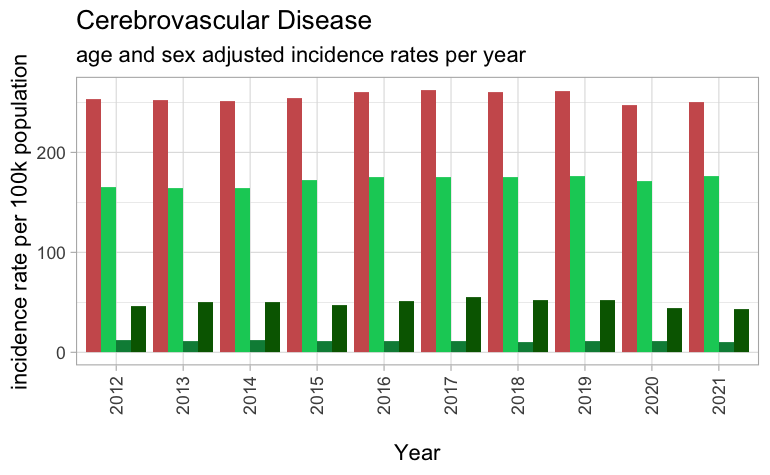

```r
plot_diagnosis_incidences <- activity_hb %>%
  select(financial_year, hbr, age_group, sex, admission_type, diagnosis, number_of_discharges, crude_rate, easr) %>%
  filter(age_group == "All",
         admission_type == "Emergency",
         sex == "All",
         hbr == "S92000003") %>%
  mutate(diagnosis = recode(diagnosis, "TIAs and related syndromes" = "TIA")) %>%
  mutate(financial_year = recode(financial_year, "2012/13" = "2012",
                                "2013/14" = "2013",
                                "2014/15" = "2014",
                                "2015/16" = "2015",
                                "2016/17" = "2016",
                                "2017/18" = "2017",
                                "2018/19" = "2018",
                                "2019/20" = "2019",
                                "2020/21" = "2020",
                                "2021/22" = "2021")) %>%
  group_by(financial_year, diagnosis) %>%
  summarise(total_incidences_easr = sum(easr)) %>%
  ggplot() +
  aes(x = financial_year, y = total_incidences_easr, fill = diagnosis) +
  geom_col(position = "dodge") +
  theme_light(base_size = 15) +
  theme(axis.text.x = element_text(angle = 90, vjust = 0.5, hjust = 1),
        legend.position = "none",
        legend.text = element_text(size = 10)) +
  labs(
    x = "\nYear",
    y = "incidence rate per 100k population",
    title = "Cerebrovascular Disease",
    subtitle = "age and sex adjusted incidence rates per year"
  ) +
   scale_fill_manual(
    values = c(
      "Cerebrovascular Disease" = "indianred",
      "Stroke" = "springgreen3",
      "Subarachnoid Haemorrhage" = "springgreen4",
      "TIA" = "darkgreen")
    )
plot_diagnosis_incidences

# save the plot:
ggsave(plot_diagnosis_incidences, filename = "plot_diagnosis_incidences_2.pdf",
       path = "../outputs/", width = 19, height = 12, units = "cm")
```

Graph shows the number of stroke incidences (age-sex standardised) in Scotland over the years 2012/13 - 2021/22 divided for diagnosis type. Majority of cases are diagnosed as Cerebrovascular disease, as expected since all types are classified as Cerebrovascular Disease. Stroke is the most common diagnosed type of CD.

Small number of cases are diagnosed as TIA, followed by Subarachnoid Haemorrhage. We see an initial increase until 2016 after incidence rates are more stable. Largest differences are found in Stroke, while TIA and Subarachnoid Haemorrhage are relatively stable across all years.

**What is the number of total stroke incidences split per admission type?**

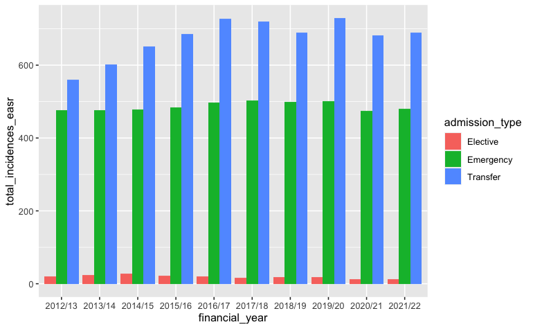

```r
activity_hb %>%
  select(financial_year, hbr, age_group, sex, admission_type, diagnosis, number_of_discharges, crude_rate, easr) %>%
  filter(age_group == "All",
         admission_type != "All",
         sex == "All",
         hbr == "S92000003") %>%
  group_by(financial_year, admission_type) %>%
  summarise(total_incidences_easr = sum(easr)) %>%
  ggplot() +
  aes(x = financial_year, y = total_incidences_easr, fill = admission_type) +
  geom_col(position = "dodge")
```

Graph shows the total number of stroke incidences (age-sex standardised) in Scotland over the years 2012/13 - 2021/22 split for admission type. Largest number of incidences are transfered patients, followed by emergency cases. A small minority of admitted incidences are elective.

#### 3B. General insights Stroke mortality per hb

**What is the stroke mortality rate in Scotland per year?**

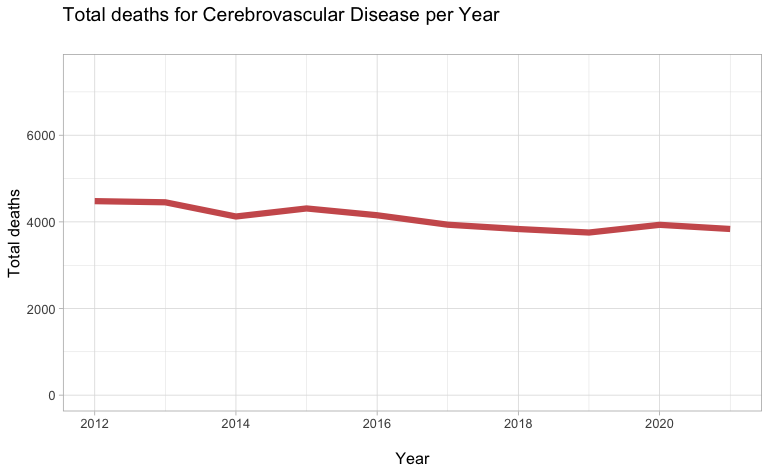

```r
mortality_hb %>%
  select(year, hbr, age_group, sex, diagnosis, number_of_deaths) %>%
  filter(age_group == "All",
         sex == "All",
         hbr == "S92000003",
         diagnosis == "Cerebrovascular Disease") %>%
  group_by(year) %>%
  summarise(total_deaths = sum(number_of_deaths)) %>%
  ggplot() +
  aes(x = year, y = total_deaths) +
  geom_line(aes(group = 1), colour = "indianred", size = 2) +
  theme_light() +
  labs(
    x = "\nYear",
    y = "Total deaths",
    title = "Total deaths for Cerebrovascular Disease per Year\n"
  ) +
  scale_y_continuous(limits = c(0, 7500))
```

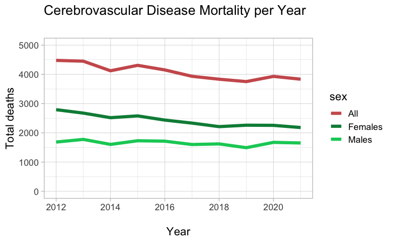

```r
#Saved for presentation: absolute stroke mortality rate in Scotland including gender:
mortality_absolute_gender <- mortality_hb %>%
  select(year, hbr, age_group, sex, diagnosis, number_of_deaths) %>%
  filter(age_group == "All",
         #sex == "All",
         hbr == "S92000003",
         diagnosis == "Cerebrovascular Disease") %>%
  group_by(year, sex) %>%
  summarise(total_deaths = sum(number_of_deaths)) %>%
  ggplot() +
  aes(x = year, y = total_deaths, colour = sex) +
  geom_line(aes(group = sex), size = 2) +
  theme_light(base_size = 15) +
  labs(
    x = "\nYear",
    y = "Total deaths",
    title = "Cerebrovascular Disease Mortality per Year\n"
  ) +
  scale_y_continuous(limits = c(0, 5000)) +
  scale_colour_manual(
    values = c(
      "All" = "indianred",
      "Males" = "springgreen3",
      "Females" = "springgreen4")
    )
mortality_absolute_gender
```

```r
# ggsave(mortality_absolute_gender, filename = "mortality_absolute_gender.pdf",
       path = "../outputs/", width = 19, height = 12, units = "cm")
```

```
Error: unexpected ',' in "       path = "../outputs/","
```

However this gives the absolute number of deaths, which are not standardised for age and sex composition differences in the population across years. The population size changes and you want to standardise for this.

**age-sex standardised stroke deaths in Scotland per year**

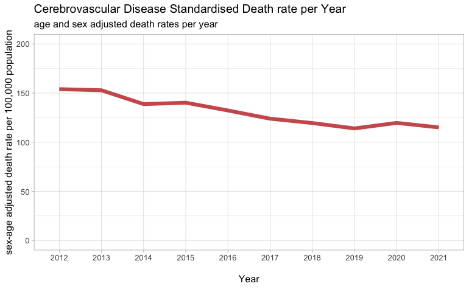

```r
mortality_hb %>%
  select(year, hbr, age_group, sex, diagnosis, number_of_deaths, easr, crude_rate) %>%
  filter(age_group == "All",
         sex == "All",
         hbr == "S92000003") %>%
  group_by(year) %>%
  summarise(total_deaths_easr = sum(easr)) %>%
  ggplot() +
  aes(x = as.factor(year), y = total_deaths_easr) +
  geom_line(aes(group = 1), colour = "indianred", size = 2) +
  theme_light() +
  labs(
    x = "\nYear",
    y = "sex-age adjusted death rate per 100,000 population",
    title = "Cerebrovascular Disease Standardised Death rate per Year",
    subtitle = "age and sex adjusted death rates per year"
  ) +
  scale_y_continuous(limits = c(0, 200))
```

Graph shows the age-sex standardised mortality rate due to Cerebrovascular Disease in Scotland over the year 2012-2021. Total number of deaths has decreased over the years comparing start to end year, similar to the graph above (but here standardised to enable comparison)

**What is the number of deaths split per diagnosis type?**

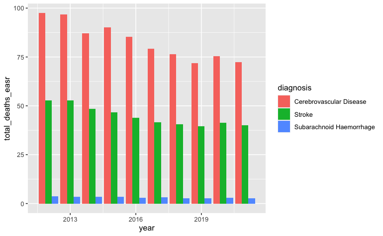

```r
mortality_hb %>%
  select(year, hbr, age_group, sex, diagnosis, number_of_deaths, easr) %>%
  filter(age_group == "All",
         sex == "All",
         hbr == "S92000003") %>%
  group_by(year, diagnosis) %>%
  summarise(total_deaths_easr = sum(easr)) %>%
  ggplot() +
  aes(x = year, y = total_deaths_easr, fill = diagnosis) +
  geom_col(position = "dodge")
```

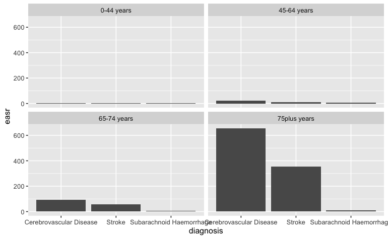

```r
mortality_hb %>%
  select(year, hbr, age_group, sex, diagnosis, number_of_deaths, easr) %>%
  filter(sex == "All",
         hbr == "S92000003",
         year == "2020",
         age_group != "All",
         age_group != "under75 years") %>%
  #group_by(diagnosis) %>%
 # summarise(total_deaths_easr = sum(easr)) %>%
  ggplot() +
  aes(x = diagnosis, y = easr) +
  geom_col(position = "dodge") +
  facet_wrap(~ age_group)
```

The first graph shows the age-sex standardised mortality rate due to Cerebrovascular Disease, and its most common diagnosis types, in Scotland over the year 2012-2021. Majority of deaths are diagnosed as strokes. Only a minority is caused by Subarachnoid haemorrhage.

The second graph introduces an additional layer/ split by age group. We observe that people aged 75+ are most commonly dying from Cerebrovascular Disease and all of its types. The data is age-sex standardised and we can therefore comapre the data. In total 600 per 100k people that are 75+ die from CD, while this is 100 per 100k or less for all remaining age groups.

#### 3C. Stroke mortality per SIMD

Visualise the number of deaths (use age-sex standardised rate per 100k population) and split the data per SIMD (Scottish Index of Multiple Deprivation)

```r
head(mortality_simd)
```

| quintile | number_of_deaths | crud_rate | easr_rate | year |
| --- | --- | --- | --- | --- |
| 1 | 957 | 88.8 | 115.9 | 2011 |
| 1 | 931 | 86.5 | 110.6 | 2012 |
| 1 | 921 | 85.6 | 110.0 | 2013 |
| 1 | 806 | 75.4 | 94.0 | 2014 |
| 1 | 956 | 89.1 | 112.1 | 2015 |
| 1 | 849 | 78.7 | 101.7 | 2016 |

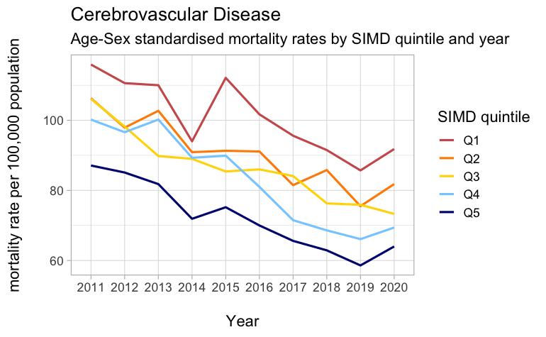

```r
plot_cd_mortality_simd <- mortality_simd %>%
  mutate(quintile = recode(quintile,
                           "1" = "Q1",
                           "2" = "Q2",
                           "3" = "Q3",
                           "4" = "Q4",
                           "5" = "Q5")) %>%
  ggplot() +
  aes(x = as.factor(year), y = easr_rate, group = quintile, colour = quintile) +
  geom_line(size = 1) +
  scale_colour_manual(
    values = c(
      "Q1" = "indianred",
      "Q2" = "darkorange",
      "Q3" = "gold",
      "Q4" = "skyblue1",
      "Q5" = "navyblue"
    )
  ) +
  theme_light(base_size = 15) +
  labs(
    x = "\nYear",
    y = "mortality rate per 100,000 population\n",
    title = "Cerebrovascular Disease",
    subtitle = "Age-Sex standardised mortality rates by SIMD quintile and year",
    colour = "SIMD quintile")

plot_cd_mortality_simd
```

```r
# save the plot:
# ggsave(plot_cd_mortality_simd, filename = "cd_mortality_simd_2.pdf",
       path = "../outputs/", width = 19, height = 12, units = "cm")
```

```
Error: unexpected ',' in "       path = "../outputs/","
```

Graph shows the age-sex standardised mortality rates (per 100,000 people) per SIMD quintile. We see a decrease in death rates across all SIMD quintiles, but we do observe that mortality rate for CD is higher in areas of higher deprivation.

#### 4A. Stroke incidence rate - demographics

Analyse/visualise the number of incidences (use age-sex standardised rate per 100k population) split per age-group and sex

**sex**

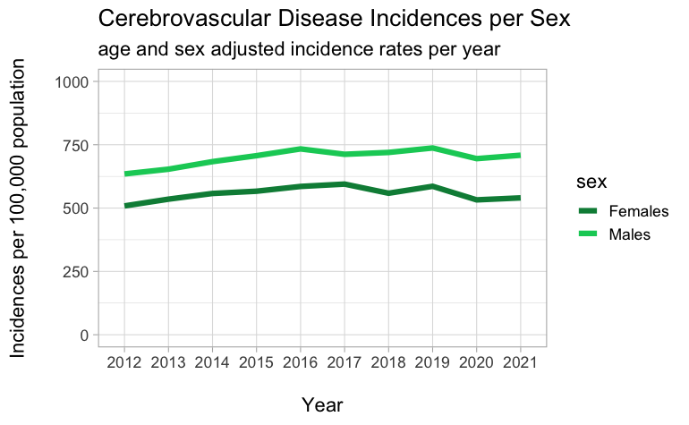

```r
plot_cd_incidence_sex <- activity_hb %>%
  select(financial_year, hbr, age_group, sex, admission_type, diagnosis, number_of_discharges, crude_rate, easr) %>%
  filter(age_group == "All",
         admission_type == "All",
         sex == "Males" | sex == "Females",
         hbr == "S92000003",
         diagnosis == "Cerebrovascular Disease") %>%
  mutate(financial_year = recode(financial_year, "2012/13" = "2012",
                                "2013/14" = "2013",
                                "2014/15" = "2014",
                                "2015/16" = "2015",
                                "2016/17" = "2016",
                                "2017/18" = "2017",
                                "2018/19" = "2018",
                                "2019/20" = "2019",
                                "2020/21" = "2020",
                                "2021/22" = "2021")) %>%
  group_by(financial_year, sex) %>%
  summarise(total_incidences_easr = sum(easr)) %>%
  ggplot() +
  aes(x = financial_year, y = total_incidences_easr) +
  geom_line(aes(group = sex, colour = sex), size = 2) +
  theme_light(base_size = 15) +
  labs(
    x = "\nYear",
    y = "Incidences per 100,000 population\n",
    title = "Cerebrovascular Disease Incidences per Sex",
    subtitle = "age and sex adjusted incidence rates per year"
  ) +
  scale_y_continuous(limits = c(0, 1000)) +
  scale_colour_manual(
    values = c(
      "Males" = "springgreen3",
      "Females" = "springgreen4")
    )
plot_cd_incidence_sex
```

```r
# save the plot:
# ggsave(plot_cd_incidence_sex, filename = "cd_incidence_sex.pdf",
#       path = "../outputs/", width = 19, height = 12, units = "cm")
```

Graph shows the age-sex standardised incidence rates (per 100,000 people) split per sex. We see a slight increase in incidence rates in both Males and Females, with a similar pattern. Overall we do observe that incidence rates for CD is higher in Males compared to Females.

**age_group**

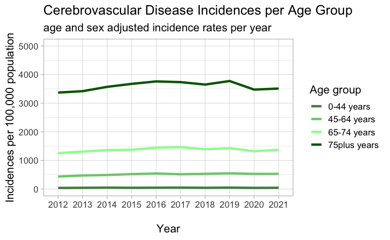

```r
plot_cd_incidences_age <- activity_hb %>%
  select(financial_year, hbr, age_group, sex, admission_type, diagnosis, number_of_discharges, crude_rate, easr) %>%
  filter(age_group == "0-44 years" | age_group == "45-64 years" |
           age_group == "65-74 years" | age_group == "75plus years",
         admission_type == "All",
         sex == "All",
         hbr == "S92000003",
         diagnosis == "Cerebrovascular Disease") %>%
  mutate(financial_year = recode(financial_year, "2012/13" = "2012",
                                "2013/14" = "2013",
                                "2014/15" = "2014",
                                "2015/16" = "2015",
                                "2016/17" = "2016",
                                "2017/18" = "2017",
                                "2018/19" = "2018",
                                "2019/20" = "2019",
                                "2020/21" = "2020",
                                "2021/22" = "2021")) %>%
  group_by(financial_year, age_group) %>%
  summarise(total_incidences_easr = sum(easr)) %>%
  ggplot() +
  aes(x = financial_year, y = total_incidences_easr) +
  geom_line(aes(group = age_group, colour = age_group), size = 1.5) +
  theme_light(base_size = 15) +
  labs(
    x = "\nYear",
    y = "Incidences per 100,000 population",
    title = "Cerebrovascular Disease Incidences per Age Group",
    subtitle = "age and sex adjusted incidence rates per year",
    colour = "Age group"
  ) +
  scale_y_continuous(limits = c(0, 5000)) +
  scale_colour_manual(
    values = c(
       "0-44 years" = "palegreen4",
      "45-64 years" = "palegreen3",
      "65-74 years" = "palegreen1",
      "75plus years" = "darkgreen")
    )
plot_cd_incidences_age
```

```r
# save the plot
# ggsave(plot_cd_incidences_age, filename = "cd_incidences_age.pdf",
#       path = "../outputs/", width = 19, height = 12, units = "cm")
```

Graph shows the age-sex standardised incidence rates (per 100,000 people) split per age group. We see a slight increase in incidence rates across all age groups. Overall we do observe that incidence rates for CD is higher in the older age groups, while much lower in younger aged people.

#### 4B. Stroke mortality rate - demographics

Visualise the number of deaths (use age-sex standardised rate per 100k population) split per age-group and sex

**sex**

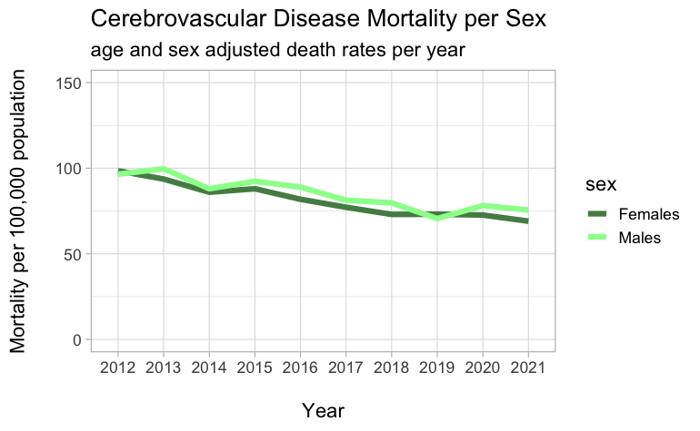

```r
plot_cd_mortality_sex <- mortality_hb %>%
  select(year, hbr, age_group, sex, diagnosis, number_of_deaths, easr, crude_rate) %>%
  filter(age_group == "All",
         sex == "Males" | sex == "Females",
         hbr == "S92000003",
         diagnosis == "Cerebrovascular Disease") %>%
  group_by(year, sex) %>%
  summarise(total_deaths_easr = sum(easr)) %>%
  ggplot() +
  aes(x = as.factor(year), y = total_deaths_easr) +
  geom_line(aes(group = sex, colour = sex), size = 2) +
  theme_light(base_size = 15) +
  labs(
    x = "\nYear",
    y = "Mortality per 100,000 population\n",
    title = "Cerebrovascular Disease Mortality per Sex",
    subtitle = "age and sex adjusted death rates per year"
  ) +
  scale_y_continuous(limits = c(0, 150)) +
  scale_colour_manual(
    values = c(
      "Females" = "palegreen4",
      "Males" = "palegreen1")
    )
plot_cd_mortality_sex
```

```r
# save plot
#ggsave(plot_cd_mortality_sex, filename = "cd_mortality_sex_2.pdf",
#       path = "../outputs/", width = 19, height = 12, units = "cm")
```

Graph shows the age-sex standardised mortality rates (per 100,000 people) split per sex. Different from the increase seen in incidence rates above, here we see a decrease in mortality rates in both sexes. Overall we do observe that mortality rates for CD is slightly higher in Males in the most recent year for which data is available.

**age_group**

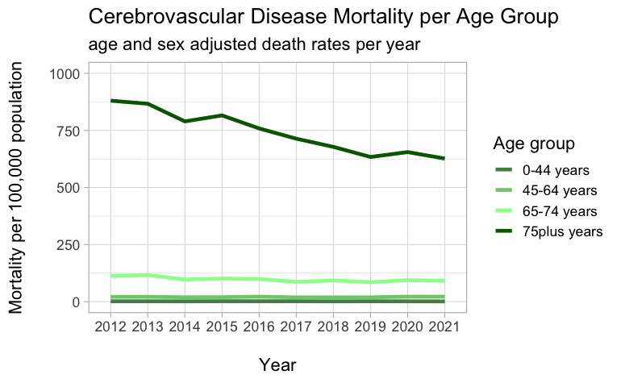

```r
plot_cd_mortality_age <- mortality_hb %>%
  select(year, hbr, age_group, sex, diagnosis, number_of_deaths, easr, crude_rate) %>%
  filter(age_group == "0-44 years" | age_group == "45-64 years" |
           age_group == "65-74 years" | age_group == "75plus years",
         sex == "All",
         hbr == "S92000003",
         diagnosis == "Cerebrovascular Disease") %>%
  group_by(year, age_group) %>%
  summarise(total_deaths_easr = sum(easr)) %>%
  ggplot() +
  aes(x = as.factor(year), y = total_deaths_easr) +
  geom_line(aes(group = age_group, colour = age_group), size = 1.5) +
  theme_light(base_size = 15) +
  labs(
    x = "\nYear",
    y = "Mortality per 100,000 population\n",
    title = "Cerebrovascular Disease Mortality per Age Group",
    subtitle = "age and sex adjusted death rates per year",
    colour = "Age group"
  ) +
  scale_y_continuous(limits = c(0, 1000)) +
  scale_colour_manual(
    values = c(
      "0-44 years" = "palegreen4",
      "45-64 years" = "palegreen3",
      "65-74 years" = "palegreen1",
      "75plus years" = "darkgreen")
    )
plot_cd_mortality_age
```

```r
# save the plot
# ggsave(plot_cd_mortality_age, filename = "cd_mortality_age.pdf",
#       path = "../outputs/", width = 19, height = 12, units = "cm")
```

#### 5. Stroke mortality and incidences per health board

Visualise the number of deaths and incidence rates (both age-sex standardised rate per 100k population) split per health board, to see changing patterns and the differences across the boards.

**mortality rate**

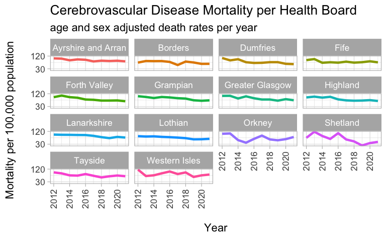

This plot shows 14 graphs each showing the age-and sex- adjusted mortality rates of Cerebrovascular disease for the years 2012-2021, for the 14 health boards in Scotland. (for full resolution/sized picture, please extend!)

The patterns do differ across health boards, with high similarity across smaller hb’s: Orkney, Shetland and Western Isles. Generally, all other healthboards show a decreasing trend in deaths due to DC.

**incidence rates**

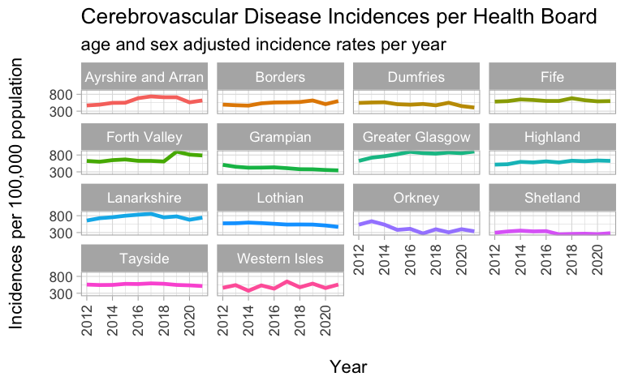

```r
# incidences

incidences_per_hb_wrap <- activity_hb %>%
  filter(hbr != "S92000003",
         age_group == "All",
         sex == "All",
         diagnosis == "Cerebrovascular Disease",
         admission_type == "All") %>%
  mutate(hbr = recode(hbr, "S08000015" = "Ayrshire and Arran",
              "S08000016" = "Borders",
              "S08000017" = "Dumfries",
              "S08000019" = "Forth Valley",
              "S08000020" = "Grampian",
              "S08000022" = "Highland",
              "S08000024" = "Lothian",
              "S08000025" = "Orkney",
              "S08000026" = "Shetland",
              "S08000028" = "Western Isles",
              "S08000029" = "Fife",
              "S08000030" = "Tayside",
              "S08000031" = "Greater Glasgow",
              "S08000032" = "Lanarkshire")) %>%
  mutate(financial_year = recode(financial_year, "2012/13" = 2012,
                                "2013/14" = 2013,
                                "2014/15" = 2014,
                                "2015/16" = 2015,
                                "2016/17" = 2016,
                                "2017/18" = 2017,
                                "2018/19" = 2018,
                                "2019/20" = 2019,
                                "2020/21" = 2020,
                                "2021/22" = 2021)) %>%
  ggplot() +
  aes(x = financial_year, y = easr) +
  geom_line(aes(group = hbr, colour = hbr), size = 1.5) +
  theme_light(base_size = 15) +
  facet_wrap(~ hbr) +
  theme(axis.text.x = element_text(angle = 90, vjust = 0.5, hjust = 1),
        legend.position = "none",
        legend.text = element_text(size = 10),
        strip.text = element_text(size=12)) +
   scale_y_continuous(breaks = c(300, 800)) +
  labs(
    x = "\nYear",
    y = "Incidences per 100,000 population\n",
    title = "Cerebrovascular Disease Incidences per Health Board",
    subtitle = "age and sex adjusted incidence rates per year")

incidences_per_hb_wrap
```

```r
# save the plot
# ggsave(incidences_per_hb_wrap, filename = "incidences_per_hb_wrap.pdf",
#       path = "../outputs/", width = 19, height = 15, units = "cm")
```

This plot shows 14 graphs each showing the age-and sex- adjusted incidence rates of Cerebrovascular disease for the years 2012-2021, for the 14 health boards in Scotland. (for full resolution/sized picture, please extend!)

The patterns do differ (more than mortality rates) across health boards, with hb’s Glasgow, Forth Valley, Ayrshire, Border experiencing an increase in CD incidences. Lothian, Tayside, Grampian and Dumfries show a decreasing trend in CD incidences.

#### 6. Percentage change in incidence and mortality rates for period 2012-2021 for major demographics

Below percentage change are calculated for the change in incidence and mortality rates for Cerebrovascular disease for major demographics (age groups and sex)

```r
#mortality - age_group
mortality_hb %>%
  filter(year == 2012 | year == 2021,
         hbr == "S92000003",
         age_group != "All" & age_group != "under75 years",
         diagnosis == "Cerebrovascular Disease",
         sex == "All") %>%
  group_by(year, age_group) %>%
  summarise(total_easr = sum(easr))
```

| year | age_group | total_easr |
| --- | --- | --- |
| 2012 | 0-44 years | 1.602247 |
| 2012 | 45-64 years | 21.011255 |
| 2012 | 65-74 years | 112.518163 |
| 2012 | 75plus years | 880.229957 |
| 2021 | 0-44 years | 1.016755 |
| 2021 | 45-64 years | 21.710826 |
| 2021 | 65-74 years | 91.325213 |
| 2021 | 75plus years | 626.790120 |

**Mortality change in easr - 2012 vs 2021:**

```r
# 75plus years
1-(626.790120   /880.229957) #-0.28
```

```
[1] 0.2879246
```

```r
#incidences - age_group
activity_hb %>%
  filter(financial_year == "2012/13" | financial_year == "2021/22",
         hbr == "S92000003",
         age_group != "All" & age_group != "under75 years",
         diagnosis == "Cerebrovascular Disease",
        admission_type == "All",
        sex == "All") %>%
  group_by(financial_year, age_group) %>%
  summarise(total_easr = sum(easr))
```

| financial_year | age_group | total_easr |
| --- | --- | --- |
| 2012/13 | 0-44 years | 38.54098 |
| 2012/13 | 45-64 years | 435.93063 |
| 2012/13 | 65-74 years | 1255.69256 |
| 2012/13 | 75plus years | 3371.00064 |
| 2021/22 | 0-44 years | 43.89090 |
| 2021/22 | 45-64 years | 530.34933 |
| 2021/22 | 65-74 years | 1372.51587 |
| 2021/22 | 75plus years | 3511.62947 |

**Incidence change in easr - 2012 vs 2021:**

```r
# 75plus years
1-(3511.62947   /3371.00064) # +0.04
```

```
[1] -0.04171724
```